# Exercício: SARIMA no comércio varejista brasileiro

- Mostrar o código
- Esconder o código
- Ver o código fonte

PMC/IBGE · Varejo ampliado · Rio de Janeiro

Autor

BG

Data de Publicação

28/10/2026

## Sobre o exercício

A base é a **PMC** (Pesquisa Mensal do Comércio) do IBGE: índice de volume de vendas no **comércio varejista ampliado** (inclui veículos e materiais de construção), por **Unidade da Federação**, mensal de jan/2004 em diante. Base 2022 = 100, **sem ajuste sazonal**.

Você receberá **uma UF de interesse**, e deve aplicar a análise abaixo:

Setup

1. Criar repositório no GitHub para o exercício, e configurar o GitHub Pages para servir o conteúdo do repositório.
2. Clonar o repositório e criar um arquivo chamado `template-exercicio-sarima.qmd` (pode usar o template deste exercício, ou criar do zero, e pode usar jupyter notebook no lugar de Quarto, basta converter usando o comando `quarto convert`).
3. Configure o `uv` com um `.venv` para gerenciar as dependências do exercício (pode usar o `requirements.txt` deste repositório como base, ou criar o seu do zero). Obs: Não é para subir a pasta `.venv` no GitHub, ele precisa estar no seu `.gitignore`.

Código

3. Análise descritiva (linha, ACF, PACF, diferenciação) e diagnóstico de tendência/sazonalidade.
4. Testes de raiz unitária (ADF, KPSS) e estimativa de `ndiffs`.
5. Ajuste de SARIMA via `AutoARIMA(season_length=12)`.
6. Diagnóstico dos resíduos.
7. Previsão de 24 meses à frente, com intervalos de 80% e 95%.

Análise e entrega

8. Discussão dos resultados (perguntas no final).
9. Compilar este arquivo em um relatório em HTML chamado index.html e subir no repositório do GitHub que você criou para este lab.
10. Configure as github pages para servir o conteúdo do repositório, e compartilhe o link no formulário de entrega do BB.

**NotaResumo dos resultados (UF: Rio de Janeiro)**

- **Série:** tendência de alta até 2014, queda forte na recessão de 2015-16 e estagnação desde então; **sazonalidade anual marcante** (dezembro ≈ 26% acima da média do ano, fevereiro ≈ 11% abaixo).
- **Estacionariedade:** ADF, KPSS, `ndiffs` e `nsdiffs` concordam: **uma diferença regular e uma sazonal** ($d = 1$, $D = 1$).
- **Modelo:** o AutoARIMA escolheu **SARIMA(1,1,1)(1,1,1)₁₂**, próximo do modelo *airline* $(0,1,1)(0,1,1)_{12}$ sugerido pela leitura da ACF/PACF.
- **Resíduos:** sem autocorrelação (Ljung-Box com p > 0,05 nos lags 12, 24 e 36), mas **não normais** por causa do choque da pandemia (abr/2020) e do **Carnaval móvel**.
- **Previsão:** 24 meses (mar/2026 a fev/2028) preservando a sazonalidade, com intervalos que se abrem rapidamente com o horizonte.

## Setup

**Código**

```python
import warnings
warnings.filterwarnings("ignore")  # avisos de convergência e de tabela de p-valores do KPSS

import numpy as np
import pandas as pd
import matplotlib.pyplot as plt
from scipy import stats

from statsmodels.tsa.stattools import adfuller, kpss
from statsmodels.tsa.seasonal import STL
from statsmodels.graphics.tsaplots import plot_acf, plot_pacf
from statsmodels.stats.diagnostic import acorr_ljungbox

from statsforecast import StatsForecast
from statsforecast.models import AutoARIMA, ARIMA
from statsforecast.arima import ndiffs, nsdiffs, arima_string

plt.rcParams.update({
    "figure.figsize": (10, 4),
    "axes.grid": True,
    "grid.alpha": 0.3,
    "axes.spines.top": False,
    "axes.spines.right": False,
})
```

## Carregando a base PMC

A base já foi pré-processada para conter apenas as colunas relevantes, e já no formato “long” (uma linha por data + UF). O nome da coluna de data é “data”, e a coluna de interesse (índice de volume) é “volume_idx”. A coluna “uf” indica a Unidade da Federação.

**Código**

```python
pmc = pd.read_csv("https://github.com/padsInsper/202634-fa/releases/download/data/pmc_volume_uf.csv")
pmc["data"] = pd.to_datetime(pmc["data"])  # o StatsForecast exige datas, não texto
pmc.head()
```

|  | uf | data | volume_idx |
| --- | --- | --- | --- |
| 0 | Acre | 2004-01-01 | 18.16706 |
| 1 | Acre | 2004-02-01 | 17.24721 |
| 2 | Acre | 2004-03-01 | 20.77331 |
| 3 | Acre | 2004-04-01 | 19.24022 |
| 4 | Acre | 2004-05-01 | 21.46320 |

## Escolha sua UF

**Código**

```python
MINHA_UF = "Rio de Janeiro"

df_sf = (
    pmc.query("uf == @MINHA_UF")
    .rename(columns={"uf": "unique_id", "data": "ds", "volume_idx": "y"})
    [["unique_id", "ds", "y"]]
    .reset_index(drop=True)
)

# A mesma série como pd.Series com frequência mensal explícita (formato usado pelo statsmodels)
y = df_sf.set_index("ds")["y"].asfreq("MS")

print(f"{MINHA_UF}: {len(y)} observações, de {y.index.min():%m/%Y} a {y.index.max():%m/%Y} "
      f"| valores ausentes: {y.isna().sum()}")
df_sf.head()
```

```
Rio de Janeiro: 266 observações, de 01/2004 a 02/2026 | valores ausentes: 0
```

|  | unique_id | ds | y |
| --- | --- | --- | --- |
| 0 | Rio de Janeiro | 2004-01-01 | 65.54508 |
| 1 | Rio de Janeiro | 2004-02-01 | 59.19507 |
| 2 | Rio de Janeiro | 2004-03-01 | 66.94424 |
| 3 | Rio de Janeiro | 2004-04-01 | 63.28491 |
| 4 | Rio de Janeiro | 2004-05-01 | 68.77390 |

## Análise descritiva

### Gráfico de linha

**Código**

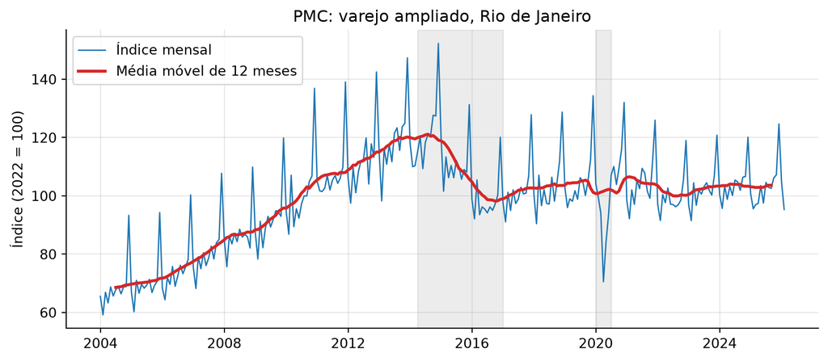

Figura 1: Índice de volume do varejo ampliado do Rio de Janeiro (base 2022 = 100). Áreas cinzas: recessões datadas pelo CODACE/FGV (2º tri/2014 a 4º tri/2016 e 1º-2º tri/2020).

```python
fig, ax = plt.subplots()
ax.axvspan(pd.Timestamp("2014-04-01"), pd.Timestamp("2016-12-31"), color="gray", alpha=0.15)
ax.axvspan(pd.Timestamp("2020-01-01"), pd.Timestamp("2020-06-30"), color="gray", alpha=0.15)
ax.plot(y, lw=1, color="C0", label="Índice mensal")
ax.plot(y.rolling(12, center=True).mean(), lw=2.2, color="C3", label="Média móvel de 12 meses")
ax.set_ylabel("Índice (2022 = 100)")
ax.set_title(f"PMC: varejo ampliado, {MINHA_UF}")
ax.legend(loc="upper left")
plt.show()
```

### Sazonalidade: perfil mensal

Para isolar a sazonalidade da tendência, dividimos cada mês pela média do seu próprio ano (só anos completos). Um valor de 1,26 em dezembro significa que dezembro vende, em média, 26% acima do mês “típico” daquele ano.

**Código**

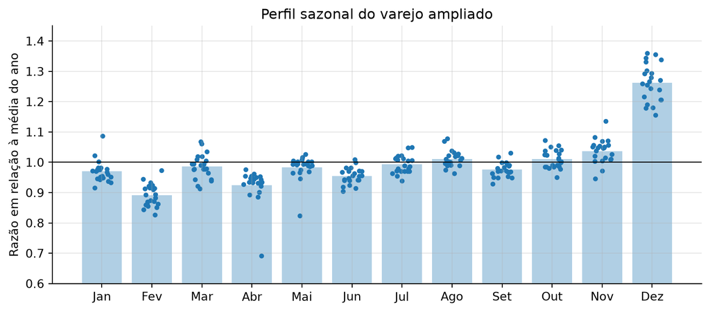

Figura 2: Perfil sazonal: índice de cada mês dividido pela média do respectivo ano (2004-2025). Cada ponto é um ano; a barra é a média.

```python
anos_completos = y[y.index.year < y.index[-1].year] if y.index[-1].month < 12 else y
razao = anos_completos / anos_completos.groupby(anos_completos.index.year).transform("mean")
perfil = razao.groupby(razao.index.month).mean()

meses = ["Jan", "Fev", "Mar", "Abr", "Mai", "Jun", "Jul", "Ago", "Set", "Out", "Nov", "Dez"]
fig, ax = plt.subplots()
ax.bar(meses, perfil.values, color="C0", alpha=0.35)
for m in range(1, 13):
    pts = razao[razao.index.month == m]
    ax.scatter(np.full(len(pts), m - 1) + np.random.default_rng(m).uniform(-0.2, 0.2, len(pts)),
               pts.values, s=10, color="C0")
ax.axhline(1, color="k", lw=0.8)
ax.set_ylim(0.6, 1.45)
ax.set_ylabel("Razão em relação à média do ano")
ax.set_title("Perfil sazonal do varejo ampliado")
plt.show()
```

**Código**

```python
perfil.set_axis(meses).round(3).to_frame("razão média").T
```

|  | Jan | Fev | Mar | Abr | Mai | Jun | Jul | Ago | Set | Out | Nov | Dez |
| --- | --- | --- | --- | --- | --- | --- | --- | --- | --- | --- | --- | --- |
| razão média | 0.97 | 0.891 | 0.986 | 0.925 | 0.984 | 0.955 | 0.993 | 1.011 | 0.977 | 1.01 | 1.037 | 1.262 |

### Decomposição STL

A STL (*Seasonal-Trend decomposition using Loess*, versão robusta a outliers) separa a série em tendência, sazonalidade e resíduo. As **forças** de tendência e sazonalidade (Wang, Smith & Hyndman, 2006) vão de 0 (ausente) a 1 (dominante).

**Código**

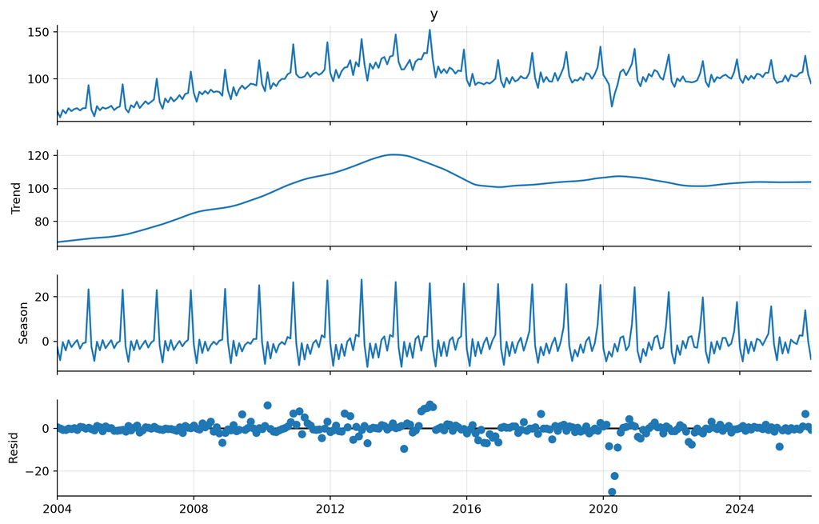

Figura 3: Decomposição STL da série do Rio de Janeiro.

```python
stl = STL(y, period=12, robust=True).fit()
fig = stl.plot()
fig.set_size_inches(10, 7)
plt.show()
```

**Código**

```python
forca_tendencia = max(0, 1 - stl.resid.var() / (stl.trend + stl.resid).var())
forca_sazonal = max(0, 1 - stl.resid.var() / (stl.seasonal + stl.resid).var())
print(f"Força da tendência: {forca_tendencia:.2f} | Força da sazonalidade: {forca_sazonal:.2f}")
```

```
Força da tendência: 0.94 | Força da sazonalidade: 0.84
```

### ACF e PACF da série original

**Código**

```python
def acf_pacf(serie, titulo, lags=48):
    """ACF e PACF lado a lado, com as defasagens sazonais (12, 24, 36, ...) marcadas."""
    fig, axes = plt.subplots(1, 2, figsize=(11, 3.6))
    plot_acf(serie.dropna(), lags=lags, ax=axes[0], title=f"ACF: {titulo}")
    plot_pacf(serie.dropna(), lags=lags, ax=axes[1], title=f"PACF: {titulo}", method="ywm")
    for ax in axes:
        for s in range(12, lags + 1, 12):
            ax.axvline(s, color="C3", ls=":", lw=1)
        ax.set_xlabel("defasagem (meses)")
    plt.tight_layout()
    plt.show()
```

**Código**

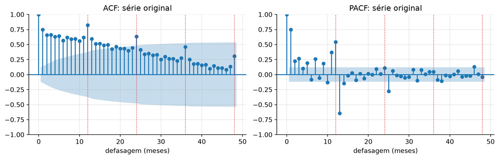

Figura 4: ACF e PACF da série original. Linhas vermelhas pontilhadas: defasagens sazonais.

```python
acf_pacf(y, "série original")
```

### Diferenciação

Testamos as três transformações candidatas: diferença regular $\Delta y_t = y_t - y_{t-1}$, diferença sazonal $\Delta_{12} y_t = y_t - y_{t-12}$ e as duas combinadas $\Delta\Delta_{12} y_t$.

**Código**

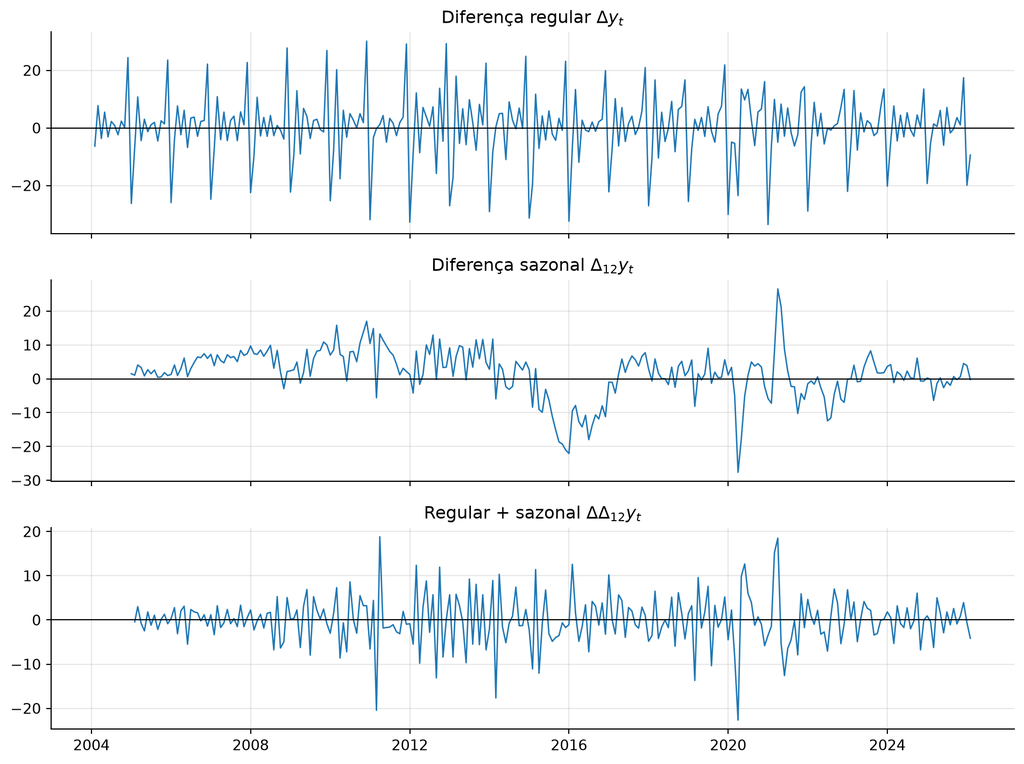

Figura 5: Série após cada tipo de diferenciação.

```python
dy = y.diff()             # (1 - B) y
d12y = y.diff(12)         # (1 - B^12) y
dd12y = y.diff(12).diff() # (1 - B)(1 - B^12) y

fig, axes = plt.subplots(3, 1, figsize=(10, 7.5), sharex=True)
for ax, (s, nome) in zip(axes, [(dy, r"Diferença regular $\Delta y_t$"),
                                (d12y, r"Diferença sazonal $\Delta_{12} y_t$"),
                                (dd12y, r"Regular + sazonal $\Delta\Delta_{12} y_t$")]):
    ax.plot(s, lw=1)
    ax.axhline(0, color="k", lw=0.8)
    ax.set_title(nome)
plt.tight_layout()
plt.show()
```

**Código**

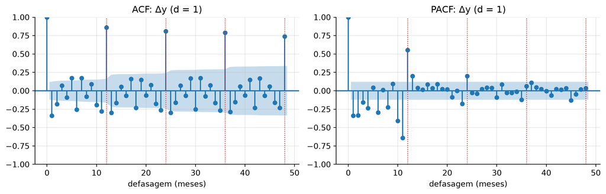

Figura 6: ACF/PACF após só a diferença regular: os picos sazonais quase não decaem.

```python
acf_pacf(dy, "Δy (d = 1)")
```

**Código**

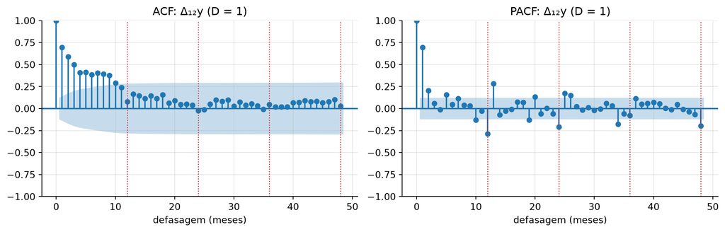

Figura 7: ACF/PACF após só a diferença sazonal: a ACF ainda decai lentamente (tendência remanescente).

```python
acf_pacf(d12y, "Δ₁₂y (D = 1)")
```

**Código**

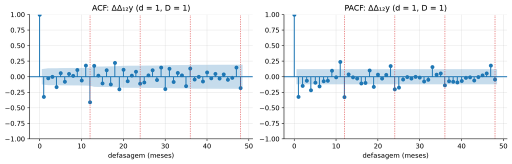

Figura 8: ACF/PACF após as duas diferenças: série estacionária, com picos isolados nos lags 1 e 12.

```python
acf_pacf(dd12y, "ΔΔ₁₂y (d = 1, D = 1)")
```

- **Só $\Delta y$:** a tendência some, mas a ACF nos lags sazonais fica em **0,86 (lag 12), 0,81 (lag 24) e 0,79 (lag 36)**. Esse decaimento quase nulo é a assinatura de uma **raiz unitária sazonal**, então falta a diferença sazonal.
- **Só $\Delta_{12} y$:** o padrão sazonal some, mas a ACF decai devagar a partir de 0,70 no lag 1 (0,59, 0,50, …): ainda há **tendência estocástica**, então falta a diferença regular.
- **$\Delta\Delta_{12} y$:** a ACF tem só dois picos relevantes, **−0,32 no lag 1** e **−0,41 no lag 12**, e corta depois deles. A PACF decai nos lags 1-2 (−0,33, −0,15) e nos lags sazonais 12 e 24 (−0,35, −0,24).

Pela tabela clássica (ACF que **corta** + PACF que **decai** = componente MA), a ACF/PACF sugere um **MA(1) regular e um MA(1) sazonal**: o modelo **airline**, SARIMA$(0,1,1)(0,1,1)_{12}$.

### Diagnóstico de tendência e sazonalidade

| Componente | Diagnóstico |
| --- | --- |
| **Tendência** | Forte (força STL = 0,94) e **não linear**: cresce de ~69 (média de 2004) até o pico da tendência em nov/2013, cai cerca de 18% entre 2014 e 2016 (recessão nacional somada à crise fiscal do estado do R… |
| **Sazonalidade** | Forte (força STL = 0,84), anual e estável: **dezembro +26%** (Natal e 13º salário) e novembro +4% (Black Friday); **fevereiro −11%** (mês curto e Carnaval) e **abril −7,5%** (Semana Santa, Tiradentes … |
| **Choques** | **Abril/2020: índice de 70,5**, queda de 28% contra abr/2019 (isolamento social), com recuperação rápida já em jul/2020. |

## Testes de raiz unitária e `ndiffs`

- **ADF:** $H_0$ = **existe** raiz unitária. p < 0,05 → rejeita → evidência de estacionariedade.
- **KPSS:** $H_0$ = a série **é estacionária**. p < 0,05 → rejeita → evidência de não estacionariedade.

O diagnóstico só é conclusivo quando os dois concordam (ADF rejeita **e** KPSS não rejeita). O KPSS do `statsmodels` só tabela p-valores entre 0,01 e 0,10, então 0,01 significa “≤ 0,01” e 0,10 significa “≥ 0,10”.

**Código**

```python
def testes(serie, nome):
    x = serie.dropna()
    p_adf = adfuller(x, autolag="AIC")[1]
    p_kpss = kpss(x, regression="c", nlags="auto")[1]
    if p_adf < 0.05 and p_kpss >= 0.05:
        conclusao = "estacionária"
    elif p_adf >= 0.05 and p_kpss < 0.05:
        conclusao = "não estacionária"
    else:
        conclusao = "testes divergem"
    return {"série": nome, "n": len(x), "ADF p-valor": p_adf, "KPSS p-valor": p_kpss,
            "conclusão": conclusao}

pd.DataFrame([
    testes(y, "original"),
    testes(dy, "Δy (d=1)"),
    testes(d12y, "Δ₁₂y (D=1)"),
    testes(dd12y, "ΔΔ₁₂y (d=1, D=1)"),
]).set_index("série").round(3)
```

Tabela 1: Testes ADF e KPSS para a série original e para cada diferenciação.

| série | n | ADF p-valor | KPSS p-valor | conclusão |
| --- | --- | --- | --- | --- |
| original | 266 | 0.171 | 0.010 | não estacionária |
| Δy (d=1) | 265 | 0.000 | 0.100 | estacionária |
| Δ₁₂y (D=1) | 254 | 0.072 | 0.023 | não estacionária |
| ΔΔ₁₂y (d=1, D=1) | 253 | 0.000 | 0.100 | estacionária |

O `statsforecast.arima` traz as mesmas funções de escolha automática do `forecast::auto.arima` do R. A função `ndiffs` aplica um teste de raiz unitária (KPSS por padrão) repetidamente até a série ficar estacionária. A `nsdiffs` faz o mesmo para a diferença sazonal (por padrão, um teste baseado na força da sazonalidade da STL).

**Código**

```python
x = y.values
print("ndiffs (diferenças regulares) na série original:")
for teste in ["kpss", "adf", "pp"]:
    print(f"  teste {teste.upper():4s}: d = {ndiffs(x, test=teste)}")

print("\nnsdiffs (diferenças sazonais, período 12):")
for teste in ["seas", "ocsb"]:
    print(f"  teste {teste.upper():4s}: D = {nsdiffs(x, period=12, test=teste)}")

# O AutoARIMA decide primeiro D e depois d na série já diferenciada sazonalmente
print(f"\nndiffs na série com diferença sazonal (Δ₁₂y): d = {ndiffs(d12y.dropna().values)}")
```

```
ndiffs (diferenças regulares) na série original:
  teste KPSS: d = 1
  teste ADF : d = 1
  teste PP  : d = 1

nsdiffs (diferenças sazonais, período 12):
  teste SEAS: D = 1
  teste OCSB: D = 1

ndiffs na série com diferença sazonal (Δ₁₂y): d = 1
```

**Conclusão:** todos os critérios apontam para **$d = 1$ e $D = 1$**. A série original não é estacionária (ADF não rejeita a raiz unitária, p = 0,17; KPSS rejeita a estacionariedade). Cada diferença sozinha não resolve: em $\Delta_{12} y$ o KPSS ainda rejeita a estacionariedade (p = 0,02) e o ADF fica no limite (p = 0,07). Com as duas diferenças, ADF e KPSS concordam que a série é estacionária.

## Modelagem

### AutoARIMA

O `AutoARIMA` do StatsForecast implementa o algoritmo de Hyndman-Khandakar:

1. escolhe $D$ (via `nsdiffs`) e depois $d$ (via `ndiffs`);
2. faz uma busca *stepwise* nas ordens $p, q, P, Q$, variando ±1 a partir de alguns modelos iniciais;
3. fica com o modelo de **menor AICc**.

**Código**

```python
sf = StatsForecast(models=[AutoARIMA(season_length=12)], freq="MS", n_jobs=1)
sf.fit(df_sf)

modelo = sf.fitted_[0, 0].model_
p, q, P, Q, s, d, D = modelo["arma"]  # ordem interna do statsforecast
print("Modelo escolhido:", arima_string(modelo).strip())
print(f"p={p}, d={d}, q={q} | P={P}, D={D}, Q={Q}, s={s}")
print(f"AICc = {modelo['aicc']:.1f} | BIC = {modelo['bic']:.1f} | "
      f"σ² = {modelo['sigma2']:.2f} (σ = {np.sqrt(modelo['sigma2']):.2f} pontos de índice)")
```

```
Modelo escolhido: ARIMA(1,1,1)(1,1,1)[12]
p=1, d=1, q=1 | P=1, D=1, Q=1, s=12
AICc = 1460.3 | BIC = 1477.7 | σ² = 17.45 (σ = 4.18 pontos de índice)
```

**Código**

```python
def tabela_coef(m):
    coef = pd.Series(m["coef"])
    ep = np.sqrt(np.diag(m["var_coef"]))
    z = coef / ep
    return pd.DataFrame({"coeficiente": coef, "erro-padrão": ep, "z": z,
                         "p-valor": 2 * stats.norm.sf(np.abs(z))}).round(3)

tabela_coef(modelo)
```

Tabela 2: Coeficientes estimados pelo AutoARIMA (erros-padrão da matriz de covariância assintótica).

|  | coeficiente | erro-padrão | z | p-valor |
| --- | --- | --- | --- | --- |
| ar1 | 0.364 | 0.055 | 6.673 | 0.000 |
| ma1 | -0.753 | 0.063 | -11.976 | 0.000 |
| sar1 | 0.114 | 0.062 | 1.845 | 0.065 |
| sma1 | -0.838 | 0.063 | -13.328 | 0.000 |

O modelo estimado é um **SARIMA(1,1,1)(1,1,1)₁₂**:

$$(1 - \phi_1 B)(1 - \Phi_1 B^{12})(1 - B)(1 - B^{12})\, y_t = (1 + \theta_1 B)(1 + \Theta_1 B^{12})\, \varepsilon_t$$

com $\hat\phi_1 = 0{,}36$, $\hat\theta_1 = -0{,}75$, $\hat\Phi_1 = 0{,}11$ e $\hat\Theta_1 = -0{,}84$.

- **Diferenças:** $d = 1$ e $D = 1$, exatamente o que os testes indicaram.
- **MA sazonal forte** ($\hat\Theta_1 = -0{,}84$): é o pico de −0,41 no lag 12 da ACF de $\Delta\Delta_{12} y$. Um $\Theta$ perto de −1 indica que o padrão sazonal é **bem estável** de um ano para o outro.
- **ARMA(1,1) regular:** a ACF/PACF mostrava só “um pico negativo no lag 1”, que o AutoARIMA modelou como ARMA(1,1) em vez de MA(1). As duas formas geram ACFs quase idênticas no lag 1 (≈ −0,3), então é uma distinção difícil de ver a olho.
- **AR sazonal** ($\hat\Phi_1 = 0{,}11$, p ≈ 0,07): pequeno e **não significativo a 5%**. Entra porque melhora o AICc, mas é o termo mais frágil do modelo.

### Comparação com o modelo sugerido pela ACF/PACF (airline)

**Código**

```python
modelos = [AutoARIMA(season_length=12),
           ARIMA(order=(0, 1, 1), seasonal_order=(0, 1, 1), season_length=12, alias="Airline")]
sf_comp = StatsForecast(models=modelos, freq="MS", n_jobs=1).fit(df_sf)

cv = StatsForecast(models=modelos, freq="MS", n_jobs=1).cross_validation(
    df=df_sf, h=12, step_size=12, n_windows=4)

linhas = []
for j, nome in enumerate(["AutoARIMA", "Airline"]):
    m = sf_comp.fitted_[0, j].model_
    res = pd.Series(m["residuals"]).iloc[13:]
    erro = cv["y"] - cv[nome]
    linhas.append({
        "modelo": f"{nome}: {arima_string(m).strip()}",
        "AICc": m["aicc"], "BIC": m["bic"],
        "Ljung-Box p (lag 24)": acorr_ljungbox(res, lags=[24], model_df=sum(m["arma"][:4]))["lb_pvalue"].iloc[0],
        "CV RMSE": np.sqrt((erro ** 2).mean()),
        "CV MAPE (%)": (erro.abs() / cv["y"]).mean() * 100,
    })
pd.DataFrame(linhas).set_index("modelo").round(3)
```

Tabela 3: AutoARIMA vs. modelo airline: critérios de informação, Ljung-Box dos resíduos e validação cruzada (4 janelas de 12 meses, origens em fev/2022 a fev/2025).

| modelo | AICc | BIC | Ljung-Box p (lag 24) | CV RMSE | CV MAPE (%) |
| --- | --- | --- | --- | --- | --- |
| AutoARIMA: ARIMA(1,1,1)(1,1,1)[12] | 1460.302 | 1477.726 | 0.132 | 3.979 | 3.030 |
| Airline: ARIMA(0,1,1)(0,1,1)[12] | 1470.433 | 1480.937 | 0.027 | 3.598 | 2.765 |

O AutoARIMA ganha no AICc e no BIC, e seus resíduos passam no Ljung-Box. O *airline* deixa autocorrelação nos resíduos (p < 0,05), principalmente no lag 12. Na validação cruzada (12 meses à frente, 4 origens), porém, o *airline* erra um pouco menos. O modelo mais parcimonioso generaliza tão bem quanto o mais rico. Seguimos com o AutoARIMA, como pede o exercício.

## Diagnóstico dos resíduos

Descartamos os primeiros $d + 12D = 13$ resíduos: com duas diferenças, o filtro de Kalman do statsforecast usa essas observações para inicializar o estado, e os resíduos delas ficam artificialmente próximos de zero.

**Código**

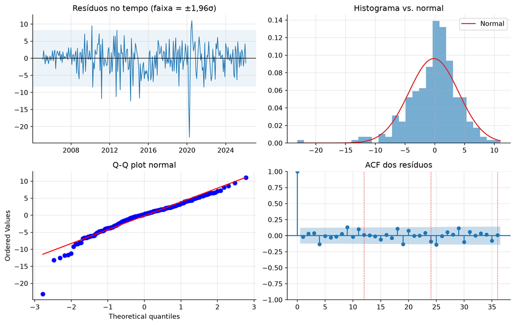

Figura 9: Diagnóstico dos resíduos do SARIMA(1,1,1)(1,1,1)₁₂.

```python
n_descartar = d + s * D
residuos = pd.Series(modelo["residuals"], index=y.index).iloc[n_descartar:]

fig, axes = plt.subplots(2, 2, figsize=(11, 7))
ax = axes[0, 0]
ax.plot(residuos, lw=1)
ax.axhline(0, color="k", lw=0.8)
ax.axhspan(-1.96 * residuos.std(), 1.96 * residuos.std(), color="C0", alpha=0.08)
ax.set_title("Resíduos no tempo (faixa = ±1,96σ)")

ax = axes[0, 1]
ax.hist(residuos, bins=30, density=True, alpha=0.6)
grade = np.linspace(residuos.min(), residuos.max(), 200)
ax.plot(grade, stats.norm.pdf(grade, residuos.mean(), residuos.std()), color="C3", label="Normal")
ax.set_title("Histograma vs. normal")
ax.legend()

stats.probplot(residuos, dist="norm", plot=axes[1, 0])
axes[1, 0].set_title("Q-Q plot normal")

plot_acf(residuos, lags=36, ax=axes[1, 1], title="ACF dos resíduos")
for lag in (12, 24, 36):
    axes[1, 1].axvline(lag, color="C3", ls=":", lw=1)
plt.tight_layout()
plt.show()
```

**Código**

```python
k = p + q + P + Q  # parâmetros ARMA estimados (graus de liberdade do Ljung-Box)
lb = acorr_ljungbox(residuos, lags=[12, 24, 36], model_df=k)
jb = stats.jarque_bera(residuos)
pd.DataFrame({
    "estatística": [*lb["lb_stat"], jb.statistic, stats.skew(residuos), stats.kurtosis(residuos, fisher=False)],
    "p-valor": [*lb["lb_pvalue"], jb.pvalue, np.nan, np.nan],
}, index=["Ljung-Box (lag 12)", "Ljung-Box (lag 24)", "Ljung-Box (lag 36)",
          "Jarque-Bera", "assimetria", "curtose"]).round(3)
```

Tabela 4: Testes formais sobre os resíduos.

|  | estatística | p-valor |
| --- | --- | --- |
| Ljung-Box (lag 12) | 13.225 | 0.104 |
| Ljung-Box (lag 24) | 27.130 | 0.132 |
| Ljung-Box (lag 36) | 43.639 | 0.082 |
| Jarque-Bera | 190.164 | 0.000 |
| assimetria | -1.032 | NaN |
| curtose | 6.712 | NaN |

**Código**

```python
maiores = residuos.reindex(residuos.abs().sort_values(ascending=False).index)[:6]
pd.DataFrame({"resíduo": maiores.round(1), "índice observado": y[maiores.index].round(1)}).rename_axis("mês")
```

Tabela 5: Os seis maiores resíduos em valor absoluto.

| mês | resíduo | índice observado |
| --- | --- | --- |
| 2020-04-01 | -23.1 | 70.5 |
| 2020-03-01 | -13.2 | 94.0 |
| 2014-03-01 | -12.5 | 110.3 |
| 2011-03-01 | -11.8 | 101.5 |
| 2015-02-01 | -11.7 | 101.6 |
| 2012-09-01 | -11.2 | 104.1 |

Três dos seis maiores resíduos caem em **março** (2020 é a pandemia; 2011 e 2014 são anos em que o **Carnaval caiu em março**, e não em fevereiro). O SARIMA impõe o mesmo padrão sazonal todo ano e não sabe que o feriado “muda de mês”. Agrupamos os resíduos de fevereiro e março pelo mês em que caiu o Carnaval para testar isso:

**Código**

```python
anos_carnaval_marco = [2011, 2014, 2019, 2022, 2025]  # anos da amostra de resíduos com Carnaval em março
fm = residuos[residuos.index.month.isin([2, 3]) & (residuos.index.year != 2020)]
(pd.DataFrame({"mês": np.where(fm.index.month == 2, "fevereiro", "março"),
               "Carnaval em": np.where(fm.index.year.isin(anos_carnaval_marco), "março", "fevereiro"),
               "resíduo": fm.values})
   .groupby(["mês", "Carnaval em"])["resíduo"].agg(["mean", "count"])
   .rename(columns={"mean": "resíduo médio", "count": "anos"}).round(2))
```

Tabela 6: Resíduo médio de fevereiro e março, conforme o mês do Carnaval (excluindo 2020).

| mês | Carnaval em | resíduo médio | anos |
| --- | --- | --- | --- |
| fevereiro | fevereiro | -1.23 | 16 |
|  | março | 1.94 | 5 |
| março | fevereiro | 2.55 | 15 |
|  | março | -7.67 | 5 |

## Previsão · 24 meses à frente

**Código**

```python
h = 24
previsao = sf.predict(h=h, level=[80, 95])
previsao.head()
```

|  | unique_id | ds | AutoARIMA | AutoARIMA-lo-95 | AutoARIMA-lo-80 | AutoARIMA-hi-80 | AutoARIMA-hi-95 |
| --- | --- | --- | --- | --- | --- | --- | --- |
| 0 | Rio de Janeiro | 2026-03-01 | 101.992751 | 93.804157 | 96.638517 | 107.346984 | 110.181344 |
| 1 | Rio de Janeiro | 2026-04-01 | 97.188152 | 87.592301 | 90.913762 | 103.462542 | 106.784003 |
| 2 | Rio de Janeiro | 2026-05-01 | 103.172591 | 92.835593 | 96.413591 | 109.931590 | 113.509588 |
| 3 | Rio de Janeiro | 2026-06-01 | 99.826755 | 88.938111 | 92.707053 | 106.946456 | 110.715399 |
| 4 | Rio de Janeiro | 2026-07-01 | 104.942395 | 93.573796 | 97.508868 | 112.375922 | 116.310994 |

**Código**

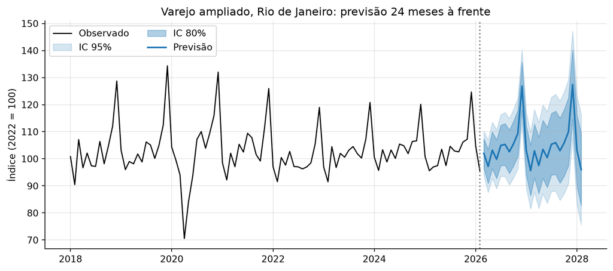

Figura 10: Previsão de 24 meses (mar/2026 a fev/2028) do SARIMA(1,1,1)(1,1,1)₁₂ com intervalos de 80% e 95%.

```python
hist = y["2018":]
fig, ax = plt.subplots(figsize=(11, 4.5))
ax.plot(hist, color="k", lw=1.2, label="Observado")
ax.fill_between(previsao["ds"], previsao["AutoARIMA-lo-95"], previsao["AutoARIMA-hi-95"],
                color="C0", alpha=0.18, label="IC 95%")
ax.fill_between(previsao["ds"], previsao["AutoARIMA-lo-80"], previsao["AutoARIMA-hi-80"],
                color="C0", alpha=0.35, label="IC 80%")
ax.plot(previsao["ds"], previsao["AutoARIMA"], color="C0", lw=1.8, label="Previsão")
ax.axvline(y.index[-1], color="gray", ls=":")
ax.set_ylabel("Índice (2022 = 100)")
ax.set_title(f"Varejo ampliado, {MINHA_UF}: previsão 24 meses à frente")
ax.legend(loc="upper left", ncol=2)
plt.show()
```

**Código**

```python
tab = previsao.assign(mês=previsao["ds"].dt.strftime("%m/%Y")).set_index("mês")
tab = tab[["AutoARIMA", "AutoARIMA-lo-80", "AutoARIMA-hi-80", "AutoARIMA-lo-95", "AutoARIMA-hi-95"]]
tab.columns = ["previsão", "IC80 inf.", "IC80 sup.", "IC95 inf.", "IC95 sup."]
tab.round(1)
```

Tabela 7: Previsões mensais com intervalos de 80% e 95% (índice, 2022 = 100).

| mês | previsão | IC80 inf. | IC80 sup. | IC95 inf. | IC95 sup. |
| --- | --- | --- | --- | --- | --- |
| 03/2026 | 102.0 | 96.6 | 107.3 | 93.8 | 110.2 |
| 04/2026 | 97.2 | 90.9 | 103.5 | 87.6 | 106.8 |
| 05/2026 | 103.2 | 96.4 | 109.9 | 92.8 | 113.5 |
| 06/2026 | 99.8 | 92.7 | 106.9 | 88.9 | 110.7 |
| 07/2026 | 104.9 | 97.5 | 112.4 | 93.6 | 116.3 |
| 08/2026 | 105.3 | 97.6 | 113.0 | 93.5 | 117.1 |
| 09/2026 | 102.6 | 94.6 | 110.6 | 90.4 | 114.9 |
| 10/2026 | 105.6 | 97.3 | 113.8 | 92.9 | 118.2 |
| 11/2026 | 109.3 | 100.8 | 117.9 | 96.3 | 122.4 |
| 12/2026 | 126.9 | 118.1 | 135.6 | 113.4 | 140.3 |
| 01/2027 | 103.1 | 94.0 | 112.1 | 89.3 | 116.9 |
| 02/2027 | 95.6 | 86.4 | 104.9 | 81.5 | 109.8 |
| 03/2027 | 102.9 | 93.0 | 112.8 | 87.8 | 118.1 |
| 04/2027 | 97.5 | 87.2 | 107.9 | 81.7 | 113.4 |
| 05/2027 | 103.5 | 92.8 | 114.2 | 87.1 | 119.9 |
| 06/2027 | 100.5 | 89.4 | 111.5 | 83.6 | 117.4 |
| 07/2027 | 105.4 | 94.0 | 116.7 | 88.0 | 122.7 |
| 08/2027 | 106.0 | 94.3 | 117.6 | 88.1 | 123.8 |
| 09/2027 | 103.0 | 91.0 | 115.0 | 84.7 | 121.3 |
| 10/2027 | 105.9 | 93.6 | 118.1 | 87.1 | 124.6 |
| 11/2027 | 109.9 | 97.4 | 122.5 | 90.7 | 129.2 |
| 12/2027 | 127.5 | 114.6 | 140.3 | 107.8 | 147.1 |
| 01/2028 | 103.2 | 90.1 | 116.3 | 83.2 | 123.3 |
| 02/2028 | 96.0 | 82.7 | 109.4 | 75.6 | 116.5 |

**Código**

```python
amplitude = previsao["AutoARIMA-hi-95"] - previsao["AutoARIMA-lo-95"]
for passo in (1, 12, 24):
    print(f"Amplitude do IC 95% em h = {passo:2d}: {amplitude.iloc[passo - 1]:5.1f} pontos "
          f"(± {amplitude.iloc[passo - 1] / 2:.1f})")
media_2025 = y["2025"].mean()
media_2027 = previsao.loc[previsao["ds"].dt.year == 2027, "AutoARIMA"].mean()
print(f"\nMédia observada em 2025: {media_2025:.1f} | média prevista para 2027: {media_2027:.1f} "
      f"({(media_2027 / media_2025 - 1) * 100:+.1f}%)")
```

```
Amplitude do IC 95% em h =  1:  16.4 pontos (± 8.2)
Amplitude do IC 95% em h = 12:  28.3 pontos (± 14.2)
Amplitude do IC 95% em h = 24:  40.9 pontos (± 20.4)

Média observada em 2025: 103.3 | média prevista para 2027: 105.1 (+1.7%)
```

A previsão **reproduz o padrão sazonal** (pico em dezembro de ≈ 127, contra 124,7 em dez/2025; vales em fevereiro e abril) e fica **ancorada no nível recente** da série (média prevista para 2027 de ≈ 105, contra 103,3 em 2025). A **amplitude do IC 95% sai de ≈ 16 pontos no 1º mês, chega a ≈ 28 em 12 meses e a ≈ 41 em 24 meses**. É a consequência direta de um modelo com duas raízes unitárias ($d = D = 1$): a variância do erro de previsão cresce sem limite com o horizonte.

## Discussão

**1. O ACF/PACF da série original sugeriu sazonalidade? E tendência? Bate com o que você viu no gráfico de linha?**

Sim para as duas. A ACF decai muito lentamente (0,75 no lag 1 e sempre positiva até o lag 48), o que indica **tendência / raiz unitária**. Por cima disso há picos nos lags 12, 24, 36 e 48 (de 0,82 a 0,31), o que indica **sazonalidade anual**. Isso bate com o gráfico de linha: alta forte até 2014, quebra em 2015-16, platô depois, e um “dente” todo dezembro. A STL confirma, com força de tendência de 0,94 e de sazonalidade de 0,84.

**2. Quantas diferenças (regular e sazonal) o AutoARIMA aplicou? E os componentes AR/MA? Conseguiu observar isso no ACF/PACF?**

Aplicou **uma regular e uma sazonal ($d = 1$, $D = 1$)**, como indicaram ADF/KPSS, `ndiffs` e `nsdiffs`. O modelo final é **SARIMA(1,1,1)(1,1,1)₁₂**. Na ACF/PACF de $\Delta\Delta_{12} y$, os picos isolados da ACF no lag 1 (−0,32) e no lag 12 (−0,41) aparecem claramente, com a PACF decaindo, e sugerem o *airline* $(0,1,1)(0,1,1)_{12}$. O MA sazonal ($\hat\Theta = -0{,}84$) e o MA regular ($\hat\theta = -0{,}75$) estão lá. Já o AR(1) regular e o AR sazonal ($\hat\Phi = 0{,}11$, não significativo) são refinamentos que o AICc capturou e que não dá para identificar a olho.

**3. Os resíduos parecem white noise? Algum padrão remanescente sazonal?**

Sim, quanto à **autocorrelação**. O Ljung-Box não rejeita ruído branco (p de 0,08 a 0,13 nos lags 12, 24 e 36), e a ACF dos resíduos nos lags sazonais é ≈ 0. **Não sobra padrão sazonal sistemático.** Os resíduos, porém, **não são normais** (curtose ≈ 6,7) por causa da pandemia e de um **efeito de calendário**: nos anos com Carnaval em março, o resíduo médio de março é ≈ −7,7 contra ≈ +2,6 nos demais. A sazonalidade “fixa” do SARIMA não acompanha feriados móveis.

**4. A previsão pareceu razoável visualmente (captura a sazonalidade, fica bem ancorada no histórico, intervalos abrem muito com o horizonte)?**

Sim. A previsão **captura a sazonalidade** (pico de dezembro, vales de fevereiro e abril) e fica **ancorada no nível recente**, em torno de 100-105, sem extrapolar a alta pré-2014. Os **intervalos abrem bastante**: o IC 95% passa de ±8 pontos no 1º mês para ±20 no 24º. Isso é coerente com $d = D = 1$, mas nos diz que, depois de ~1 ano, a previsão serve mais para o padrão sazonal do que para o nível.

**5. Que outras UFs você imagina que dariam um SARIMA bem diferente do seu (e por quê)?**

O RJ é uma economia grande, diversificada e madura, com **crescimento baixo** desde 2014 e ruído pequeno. Esperamos SARIMAs bem diferentes em:

- **Fronteira agrícola e Norte em expansão (MT, TO, RR, AC):** crescimento muito mais forte e persistente (agronegócio e, em Roraima, o aumento populacional com a migração venezuelana). A tendência tende a ser capturada por um **drift** em vez de uma diferença regular extra.
- **Distrito Federal:** renda ancorada no funcionalismo público e menos dependente do ciclo de crédito e emprego privado, o que deve dar **sazonalidade de dezembro mais fraca**.
- **UFs pequenas (AC, AP, RR, TO):** amostra da PMC menor, logo **séries mais ruidosas** e intervalos de previsão mais largos.

Para conferir essas hipóteses, rodamos o mesmo `AutoARIMA(season_length=12)` em todas as UFs:

**Código**

```python
todas = pmc.rename(columns={"uf": "unique_id", "data": "ds", "volume_idx": "y"})[["unique_id", "ds", "y"]]
sf_todas = StatsForecast(models=[AutoARIMA(season_length=12)], freq="MS", n_jobs=1).fit(todas)

linhas = []
for i, uf in enumerate(sf_todas.uids):
    m = sf_todas.fitted_[i, 0].model_
    serie = todas[todas["unique_id"] == uf].set_index("ds")["y"]
    serie = serie[serie.index.year <= 2025]
    r = serie / serie.groupby(serie.index.year).transform("mean")
    linhas.append({
        "UF": uf,
        "modelo": arima_string(m).strip(),
        "d": m["arma"][5], "D": m["arma"][6],
        "crescimento 2004→2025 (×)": serie["2025"].mean() / serie["2004"].mean(),
        "pico de dezembro": r[r.index.month == 12].mean(),
        "ruído (σ resíduo / média)": np.std(m["residuals"][13:]) / serie.mean(),
    })
(pd.DataFrame(linhas).set_index("UF")
   .sort_values("crescimento 2004→2025 (×)", ascending=False).round(2))
```

Tabela 8: AutoARIMA(season_length=12) em todas as UFs, ordenadas pelo crescimento do índice entre 2004 e 2025.

| UF | modelo | d | D | crescimento 2004→2025 (×) | pico de dezembro | ruído (σ resíduo / média) |
| --- | --- | --- | --- | --- | --- | --- |
| Tocantins | ARIMA(2,0,2)(1,1,1)[12] with drift | 0 | 1 | 5.74 | 1.18 | 0.07 |
| Acre | ARIMA(1,1,1)(0,1,1)[12] | 1 | 1 | 4.99 | 1.26 | 0.07 |
| Roraima | ARIMA(2,0,1)(0,1,1)[12] with drift | 0 | 1 | 4.50 | 1.19 | 0.05 |
| Rondônia | ARIMA(1,1,1)(0,1,2)[12] | 1 | 1 | 3.86 | 1.25 | 0.07 |
| Maranhão | ARIMA(1,1,1)(0,1,2)[12] | 1 | 1 | 3.69 | 1.25 | 0.05 |
| Amapá | ARIMA(1,0,0)(2,1,0)[12] with drift | 0 | 1 | 3.20 | 1.27 | 0.07 |
| Espírito Santo | ARIMA(1,1,2)(1,1,2)[12] | 1 | 1 | 3.13 | 1.18 | 0.06 |
| Pará | ARIMA(1,1,1)(0,1,2)[12] | 1 | 1 | 3.04 | 1.32 | 0.05 |
| Paraíba | ARIMA(1,1,1)(0,1,1)[12] | 1 | 1 | 3.03 | 1.27 | 0.06 |
| Alagoas | ARIMA(1,1,1)(0,1,2)[12] | 1 | 1 | 3.02 | 1.31 | 0.05 |
| Ceará | ARIMA(0,1,3)(1,1,2)[12] | 1 | 1 | 2.87 | 1.24 | 0.05 |
| Santa Catarina | ARIMA(2,0,1)(1,1,1)[12] with drift | 0 | 1 | 2.86 | 1.25 | 0.05 |
| Piauí | ARIMA(1,1,1)(0,1,2)[12] | 1 | 1 | 2.81 | 1.26 | 0.06 |
| Amazonas | ARIMA(2,0,2)(1,1,1)[12] with drift | 0 | 1 | 2.71 | 1.24 | 0.06 |
| Mato Grosso | ARIMA(3,0,0)(0,1,2)[12] with drift | 0 | 1 | 2.51 | 1.17 | 0.05 |
| Rio Grande do Norte | ARIMA(0,1,2)(1,1,2)[12] | 1 | 1 | 2.41 | 1.26 | 0.04 |
| Mato Grosso do Sul | ARIMA(1,1,2)(0,1,2)[12] | 1 | 1 | 2.33 | 1.20 | 0.05 |
| Sergipe | ARIMA(0,1,1)(0,1,2)[12] | 1 | 1 | 2.30 | 1.26 | 0.05 |
| Pernambuco | ARIMA(1,1,1)(0,1,2)[12] | 1 | 1 | 2.25 | 1.26 | 0.05 |
| Minas Gerais | ARIMA(3,1,2)(1,1,1)[12] | 1 | 1 | 2.02 | 1.19 | 0.04 |
| Goiás | ARIMA(0,1,1)(1,1,1)[12] | 1 | 1 | 2.01 | 1.15 | 0.05 |
| Rio Grande do Sul | ARIMA(2,0,1)(2,1,1)[12] with drift | 0 | 1 | 1.88 | 1.26 | 0.05 |
| Paraná | ARIMA(1,1,1)(1,1,1)[12] | 1 | 1 | 1.86 | 1.20 | 0.04 |
| Bahia | ARIMA(2,1,1)(0,1,2)[12] | 1 | 1 | 1.77 | 1.25 | 0.05 |
| São Paulo | ARIMA(2,1,1)(0,1,1)[12] | 1 | 1 | 1.75 | 1.21 | 0.04 |
| Rio de Janeiro | ARIMA(1,1,1)(1,1,1)[12] | 1 | 1 | 1.51 | 1.26 | 0.04 |
| Distrito Federal | ARIMA(1,1,1)(0,1,2)[12] | 1 | 1 | 1.44 | 1.17 | 0.05 |

A tabela confirma boa parte das hipóteses:

- **$D = 1$ em todas as 27 UFs.** A sazonalidade estocástica anual é universal no varejo brasileiro.
- **Sete UFs saem com $d = 0$ e drift**, uma estrutura diferente da do RJ: Tocantins (1ª em crescimento, 5,7×), Roraima (3ª, 4,5×), Amapá (6ª, 3,2×), Santa Catarina, Amazonas, Mato Grosso e Rio Grande do Sul. A relação com o crescimento existe, mas é fraca. Acre (5,0×), Rondônia (3,9×) e Maranhão (3,7×) cresceram muito e mantiveram $d = 1$, enquanto o RS (1,9×) ficou com drift. A hipótese da fronteira agrícola se confirma para TO, RR e MT, mas não para o Acre.
- O RJ tem $d = 1$ e é a **2ª UF que menos cresceu** (1,5×), à frente só do DF (1,4×).
- O **pico de dezembro** é menor no Centro-Oeste (Goiás 1,15; DF e MT 1,17) e maior no Norte e Nordeste (Pará 1,32; Alagoas 1,31). O RJ (1,26) está no meio.
- Acre, Amapá, Rondônia e Tocantins têm **ruído relativo** de 0,07, quase o dobro do RJ (0,04). Roraima é a exceção à hipótese das “UFs pequenas” (0,05).